# Unit 3 Project

2026-02-06

Below is a template to get you started on the Unit 3 Project. Make sure you edit the metadata above to include your name. For questions that include code, the template to produce `R` chunks is below. **Any code you write that produces an output must be fully visible in the HTML document you hand in!**

# Part I: Morphological Data

## Question 1

The trait means for each species are different as seen in the table. They do seem significantly different: Setosa seems to have a different trend than the other two. It has a slightly lower sepal length, a slightly higher sepal width, a significantly lower petal length, and a significantly lower petal width. The other two species’ values are closer together.

```r
iris_means <- iris %>%
  group_by(Species) %>%
  summarise(across(where(is.numeric), mean))
iris_means
```

```
## # A tibble: 3 × 5
##   Species    Sepal.Length Sepal.Width Petal.Length Petal.Width
##   <fct>             <dbl>       <dbl>        <dbl>       <dbl>
## 1 setosa             5.01        3.43         1.46       0.246
## 2 versicolor         5.94        2.77         4.26       1.33
## 3 virginica          6.59        2.97         5.55       2.03
```

## Question 2

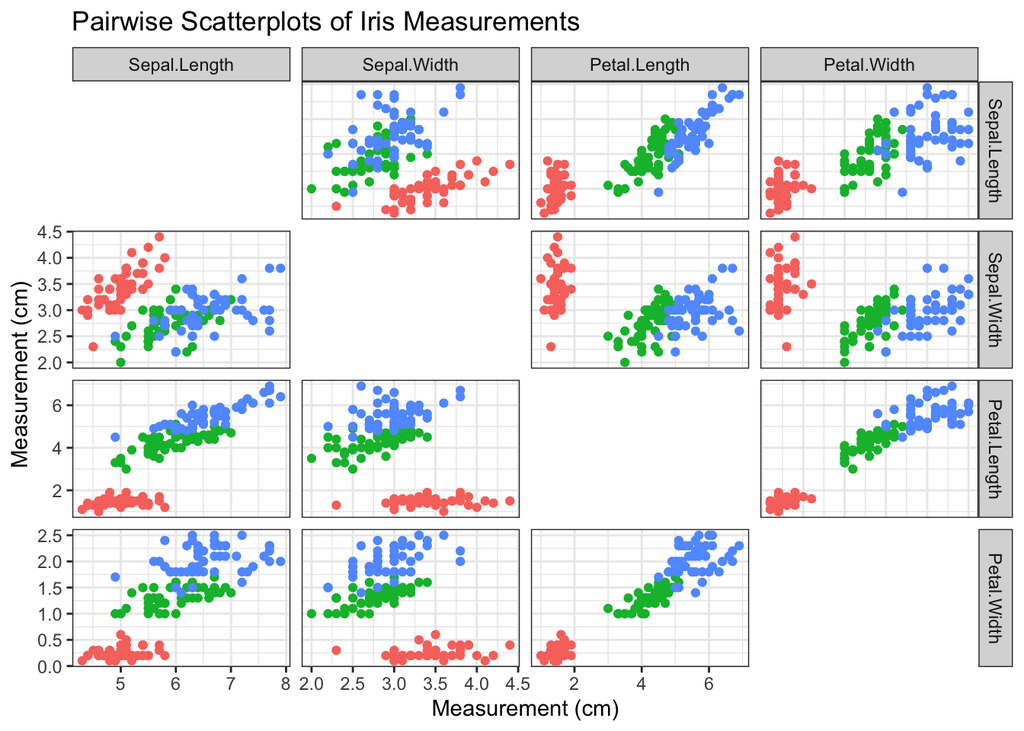

```r
ggpairs( iris, columns = c("Sepal.Length", "Sepal.Width", "Petal.Length", "Petal.Width"), mapping = aes(color = Species), upper = list(continuous = wrap("points")), lower = list(continuous = wrap("points")), diag = list(continuous = "blankDiag") ) + theme_bw() + labs( title = "Pairwise Scatterplots of Iris Measurements", x = "Measurement (cm)", y = "Measurement (cm)" )
```

```r
legend_plot <- ggplot(iris, aes(x = Sepal.Length, y = Sepal.Width, color = Species)) +
  geom_point() +
  theme_bw()
```

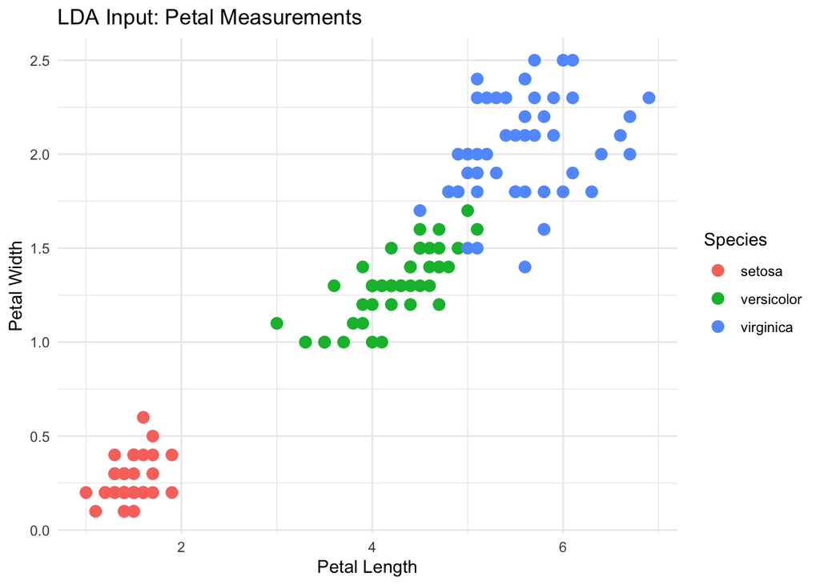

```r
lda_petals <- lda(Species ~ Petal.Length + Petal.Width, data = iris)
plot1 <- ggplot(iris, aes(x = Petal.Length, y = Petal.Width, color = Species)) +
  geom_point(size = 3) +
  labs(title = "LDA Input: Petal Measurements", x = "Petal Length", y = "Petal Width") +
  theme_minimal()
lda_sepals <- lda(Species ~ Sepal.Length + Sepal.Width, data = iris)
plot2 <- ggplot(iris, aes(x = Sepal.Length, y = Sepal.Width, color = Species)) +
  geom_point(size = 3) +
  labs(title = "LDA Input: Sepal Measurements", x = "Sepal Length", y = "Sepal Width") +
  theme_minimal()
print(plot1)
```

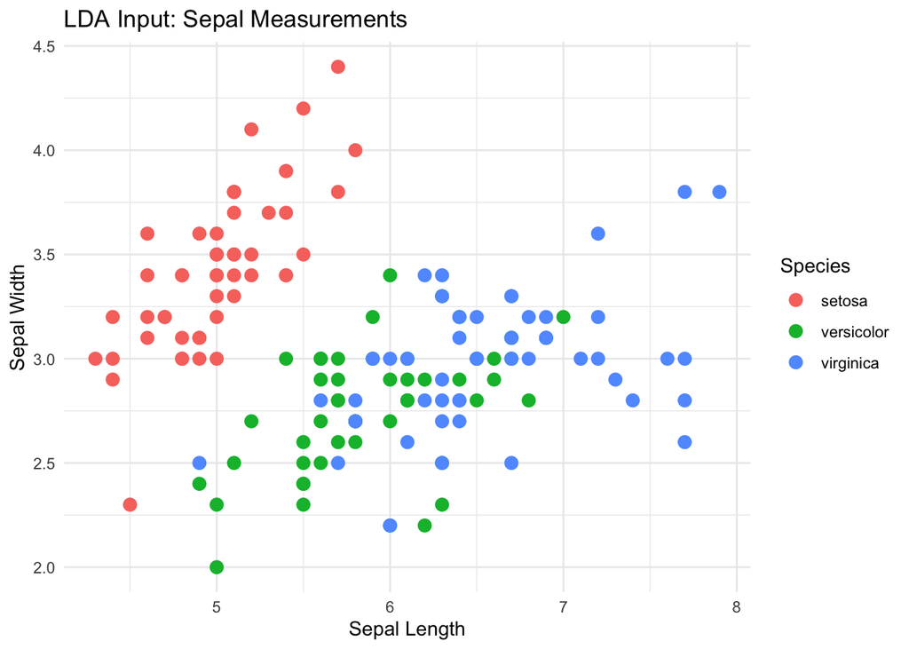

```r
print(plot2)
```

## Question 4

# Part II: Geographical and temporal data

```r
iris_gps <- read_csv("iris_gps.csv")
```

## Question 1

I see that the plant I chose is found mostly on the north and east part of the United States.

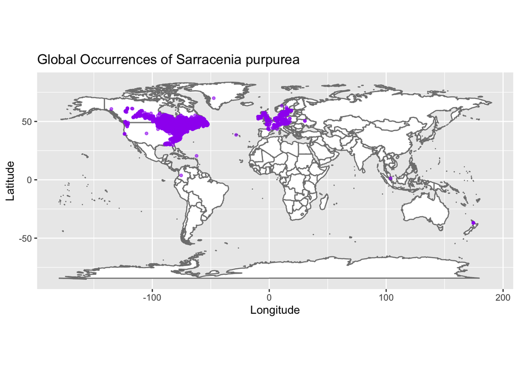

```r
trillium<-read_csv("trillium_gps.csv")

world.map <- map_data(map = "world")
state.map <- map_data(map = "state")
ggplot(world.map, aes(long, lat, group = group)) +
  geom_polygon(fill = "white", colour = "grey50") +
  coord_quickmap() +
  geom_point(data = trillium,
             aes(x = lon, y = lat, group = species),
             color = "purple", size = 1, alpha = 0.6) +
  labs(title = "Global Occurrences of Sarracenia purpurea",
       x = "Longitude", y = "Latitude")
```

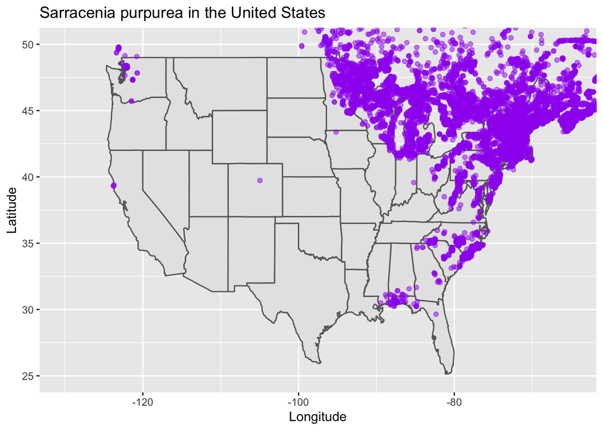

```r
ggplot() +
  geom_polygon(data = state.map,
               aes(x = long, y = lat, group = group),
               fill = "gray90", color = "gray40") +
  geom_point(data = trillium,
             aes(x = lon, y = lat),
             color = "purple", alpha = 0.5) +
  coord_cartesian(xlim = c(-130, -65),
                  ylim = c(25, 50)) +
  ggtitle("Sarracenia purpurea in the United States") +
  xlab("Longitude") +
  ylab("Latitude")
```

```r
colnames(trillium)
```

```
## [1] "species" "lat"     "lon"     "month"
```

```r
str(trillium)
```

```
## spc_tbl_ [27,906 × 4] (S3: spec_tbl_df/tbl_df/tbl/data.frame)
##  $ species: chr [1:27906] "Sarracenia purpurea" "Sarracenia purpurea" "Sarracenia purpurea" "Sarracenia purpurea" ...
##  $ lat    : num [1:27906] 39.8 40 39.9 44.6 34 ...
##  $ lon    : num [1:27906] -74.5 -74.5 -74.5 -63.5 -78.2 ...
##  $ month  : num [1:27906] 1 1 1 1 1 1 1 1 1 1 ...
##  - attr(*, "spec")=
##   .. cols(
##   ..   species = col_character(),
##   ..   lat = col_double(),
##   ..   lon = col_double(),
##   ..   month = col_double()
##   .. )
##  - attr(*, "problems")=<externalptr>
```

## Question 2

```r
us.map <- map_data(map = "usa")
lat_min  <- min(us.map$lat,  na.rm = TRUE)
lat_max  <- max(us.map$lat,  na.rm = TRUE)
lon_min  <- min(us.map$long, na.rm = TRUE)
lon_max  <- max(us.map$long, na.rm = TRUE)
cat("US bounding box:\n",
    "Lat:", lat_min, "to", lat_max, "\n",
    "Lon:", lon_min, "to", lon_max, "\n")
```

```
## US bounding box:
##  Lat: 25.12993 to 49.38323
##  Lon: -124.6813 to -67.00742
```

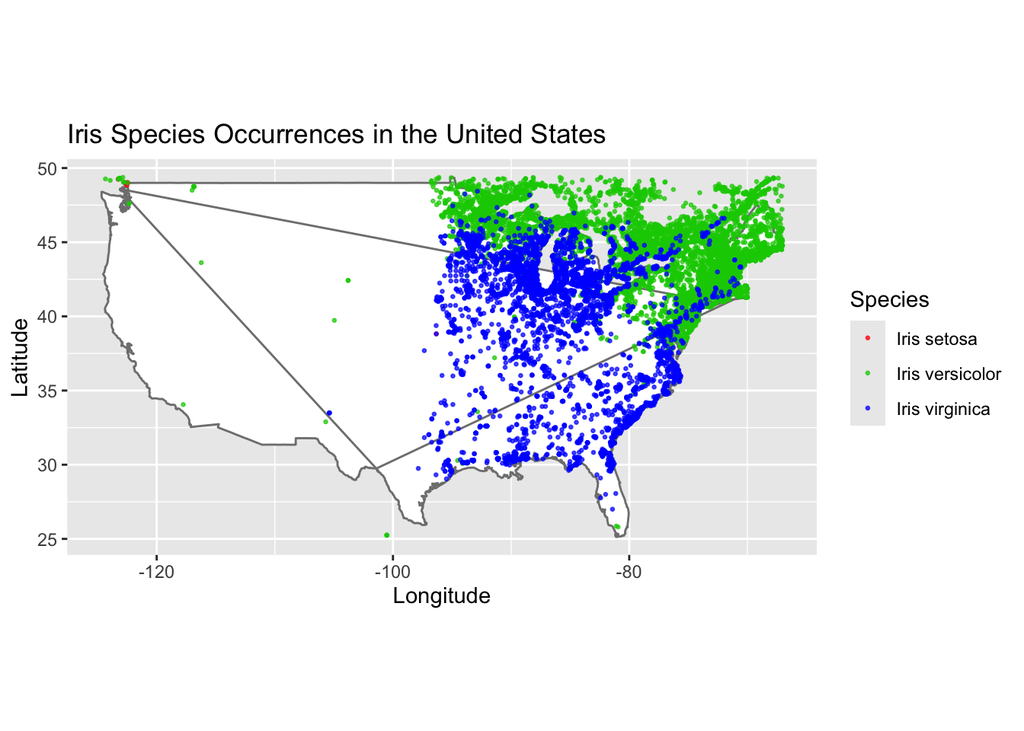

```r
iris_us <- iris_gps %>%
  filter(lat  >= lat_min, lat  <= lat_max,
         lon  >= lon_min, lon  <= lon_max)

ggplot(us.map, aes(long, lat)) +
  geom_polygon(fill = "white", colour = "grey50") +
  coord_quickmap() +
  geom_point(data = iris_us,
             aes(x = lon, y = lat, color = species),
             size = 0.5, alpha = 0.7) +
  scale_color_manual(values = c("Iris setosa"     = "red",
                                "Iris versicolor" = "green3",
                                "Iris virginica"  = "blue")) +
  labs(title = "Iris Species Occurrences in the United States",
       x = "Longitude", y = "Latitude", color = "Species")
```

## Question 3

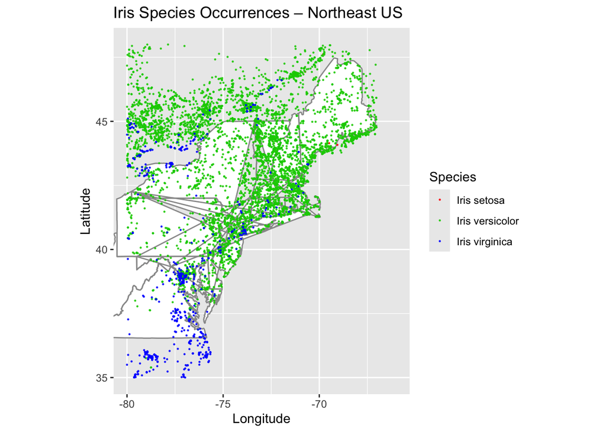

```r
ne_lon_min <- -80; ne_lon_max <- -66
ne_lat_min <-  35; ne_lat_max <-  48

iris_ne <- iris_us %>%
  filter(lon >= ne_lon_min, lon <= ne_lon_max,
         lat >= ne_lat_min, lat <= ne_lat_max)

ne.map <- map_data("state", region = c("maine", "new hampshire", "vermont", "massachusetts", "rhode island", "connecticut", "new york", "pennsylvania", "new jersey","maryland", "delaware", "west virginia", "virginia"))

ggplot(ne.map, aes(long, lat)) +
  geom_polygon(fill = "white", colour = "grey60") +
  coord_quickmap(xlim = c(ne_lon_min, ne_lon_max),
                 ylim = c(ne_lat_min, ne_lat_max)) +
  geom_point(data = iris_ne,
             aes(x = lon, y = lat, color = species),
             size = 0.2, alpha = 0.8) +
  scale_color_manual(values = c("Iris setosa"     = "red",
                                "Iris versicolor" = "green3",
                                "Iris virginica"  = "blue")) +
  labs(title = "Iris Species Occurrences – Northeast US",
       x = "Longitude", y = "Latitude", color = "Species")
```

## Question 4

I noticed that the Iris Setosa is found in the north eastern area but has very few occurences. The Iris Versicolor is found kind of all over but more towards the northern part of the East Coast. Lastly, Iris Virginica is found lower on the East Coast. Iris Versicolor cluster a lot more than the other two species and Iris Virginica is more spread out, but does overlap with Iris Versicolor a little. Iris Versicolor is the most common, then Iris Virginica, and Iris Setosa only has 2 to 3 dots so it is the least common occurrence.

Although the species overlap in some places, each of the species has its own region where it’s most common. This means that they’re geographically separated, which supported them being different species.

The geographic data shows that the species are not completely living in the same areas across their full ranges because they may stay reproductively isolated in many places. This means that the idea that they are separate species rather than one single species with different forms is highly likely.

## Question 5

Using flowering time to measure reproductive isolation has some flaws. Flowering times can change, depending on many factors like the climate, the year, and how the data was collected. Also just because two species flower at the same time does not mean they will cross pollinate. So flowering times that overlap cannot completely show whether two species are reproductively isolated.

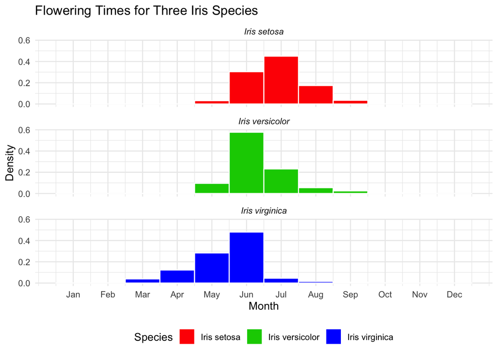

```r
month_labels <- c("Jan","Feb","Mar","Apr","May","Jun",
                  "Jul","Aug","Sep","Oct","Nov","Dec")

ggplot(data = iris_gps %>% filter(!is.na(month)),
       aes(x = month, y = after_stat(density),
           group = species, fill = species)) +
  geom_histogram(position = "dodge", binwidth = 1, color = "white") +
  facet_wrap(~species, nrow = 3) +
  scale_x_continuous(breaks = 1:12, labels = month_labels) +
  scale_fill_manual(values = c("Iris setosa"     = "red",
                               "Iris versicolor" = "green3",
                               "Iris virginica"  = "blue")) +
  labs(title = "Flowering Times for Three Iris Species",
       x = "Month", y = "Density",
       fill = "Species") +
  theme_minimal() +
  theme(legend.position = "bottom",
        strip.text = element_text(face = "italic"))
```

# Part III: Chromosomal data

```r
iris_chrom_dataset <- read_csv("Iris chromosome.csv")
head(iris_chrom_dataset)
```

```
## # A tibble: 6 × 1
##   CCDB is a community resource. If you are aware of any missing data or if any…¹
##   <chr>
## 1 "id,source,internal_id,major_group,family,genus,original_name,matched_name,re…
## 2 "ipcn-api-dl-53132,ipcn-api-dl,16600207,Angiosperms,Iridaceae,Iris,Iris acuti…
## 3 "book-atlas-flowering-plants-11026,book-atlas-flowering-plants,,Angiosperms,I…
## 4 "ipcn-api-dl-53159,ipcn-api-dl,16600226,Angiosperms,Iridaceae,Iris,Iris ewban…
## 5 "ipcn-api-dl-53194,ipcn-api-dl,16600242,Angiosperms,Iridaceae,Iris,Iris lineo…
## 6 "ipcn-api-dl-53195,ipcn-api-dl,16600242,Angiosperms,Iridaceae,Iris,Iris lineo…
## # ℹ abbreviated name:
## #   ¹`CCDB is a community resource. If you are aware of any missing data or if any of the counts are erroneous please submit it to mailto:[email protected]`
```

```r
iris_chrom_dataset <- read_csv("Iris chromosome.csv", skip = 1)
head(iris_chrom_dataset)
```

```
## # A tibble: 6 × 15
##   id      source internal_id major_group family genus original_name matched_name
##   <chr>   <chr>        <dbl> <chr>       <chr>  <chr> <chr>         <chr>
## 1 ipcn-a… ipcn-…    16600207 Angiosperms Irida… Iris  Iris acutilo… Iris acutil…
## 2 book-a… book-…          NA Angiosperms Irida… Iris  Iris acutilo… Iris acutil…
## 3 ipcn-a… ipcn-…    16600226 Angiosperms Irida… Iris  Iris ewbanki… Iris ewbank…
## 4 ipcn-a… ipcn-…    16600242 Angiosperms Irida… Iris  Iris lineola… Iris lineol…
## 5 ipcn-a… ipcn-…    16600242 Angiosperms Irida… Iris  Iris lineola… Iris lineol…
## 6 ipcn-a… ipcn-…    16602561 Angiosperms Irida… Iris  Iris acutilo… Iris acutil…
## # ℹ 7 more variables: resolved_name <chr>, taxonomic_status <chr>,
## #   gametophytic <chr>, sporophytic <chr>, parsed_n <chr>, reference <chr>,
## #   voucher <lgl>
```

```r
iris_chrom <- iris_chrom_dataset %>%
    dplyr::select(resolved_name, sporophytic, parsed_n) %>%
    separate(resolved_name, into = c("genus", "species"), sep = " ", remove = TRUE, extra = "drop")
```

## Question 1

```r
library(tidyverse)

head(iris_chrom)
```

```
## # A tibble: 6 × 4
##   genus species   sporophytic parsed_n
##   <chr> <chr>     <chr>       <chr>
## 1 Iris  acutiloba 20          10
## 2 Iris  acutiloba 20          10
## 3 Iris  acutiloba 20          10
## 4 Iris  acutiloba 20          10
## 5 Iris  acutiloba 20          10
## 6 Iris  acutiloba 20          10
```

```r
setosa_chrom <- iris_chrom %>%
    filter(species == "setosa")

setosa_chrom
```

```
## # A tibble: 17 × 4
##    genus species sporophytic parsed_n
##    <chr> <chr>   <chr>       <chr>
##  1 Iris  setosa  "38"        19
##  2 Iris  setosa  "38"        19
##  3 Iris  setosa  "38"        19
##  4 Iris  setosa  "38"        19
##  5 Iris  setosa  "38"        19
##  6 Iris  setosa  "38"        19
##  7 Iris  setosa  "36"        18
##  8 Iris  setosa  "38"        19
##  9 Iris  setosa  "38"        19
## 10 Iris  setosa  "38"        19
## 11 Iris  setosa  "38"        19
## 12 Iris  setosa  "34,36,38"  17, 18, 19
## 13 Iris  setosa  "38"        19
## 14 Iris  setosa  "\"34-36\"" 17,18
## 15 Iris  setosa  "38"        19
## 16 Iris  setosa  "c. 54"     27
## 17 Iris  setosa  "c. 54"     27
```

```r
virginica_chrom <- iris_chrom %>%
    filter(species == "virginica")

virginica_chrom
```

```
## # A tibble: 2 × 4
##   genus species   sporophytic parsed_n
##   <chr> <chr>     <chr>       <chr>
## 1 Iris  virginica 70,72       35, 36
## 2 Iris  virginica 54, 56, 70  27, 28, 35
```

```r
versicolor_chrom <- iris_chrom %>%
    filter(species == "versicolor")

versicolor_chrom
```

```
## # A tibble: 5 × 4
##   genus species    sporophytic parsed_n
##   <chr> <chr>      <chr>       <chr>
## 1 Iris  versicolor 108         54
## 2 Iris  versicolor 108         54
## 3 Iris  versicolor 108         54
## 4 Iris  versicolor 108         54
## 5 Iris  versicolor 72, 84, 105 36, 42
```

```r
iris_chrom_clean <- iris_chrom %>%
  separate_rows(sporophytic, sep = ",") %>%
  mutate(sporophytic = as.numeric(trimws(sporophytic))) %>%
  filter(!is.na(sporophytic))
get_mode <- function(x) {
  ux <- unique(x)
  ux[which.max(tabulate(match(x, ux)))]
}

chrom_mode <- iris_chrom_clean %>%
  group_by(species) %>%
  summarise(mode_sporophytic = get_mode(sporophytic))

head(chrom_mode, 20)
```

```
## # A tibble: 20 × 2
##    species        mode_sporophytic
##    <chr>                     <dbl>
##  1 acutiloba                    20
##  2 afghanica                    22
##  3 aitchisonii                  34
##  4 alberti                      24
##  5 albicans                     44
##  6 albomarginata                50
##  7 anguifuga                    34
##  8 antilibanotica               20
##  9 aphylla                      48
## 10 arenaria                     22
## 11 assadiana                    20
## 12 atrofusca                    20
## 13 atropatana                   18
## 14 atropurpurea                 20
## 15 aucheri                      24
## 16 auranitica                   20
## 17 barnumiae                    20
## 18 basaltica                    20
## 19 bicapitata                   40
## 20 biglumis                     40
```

## Question 2

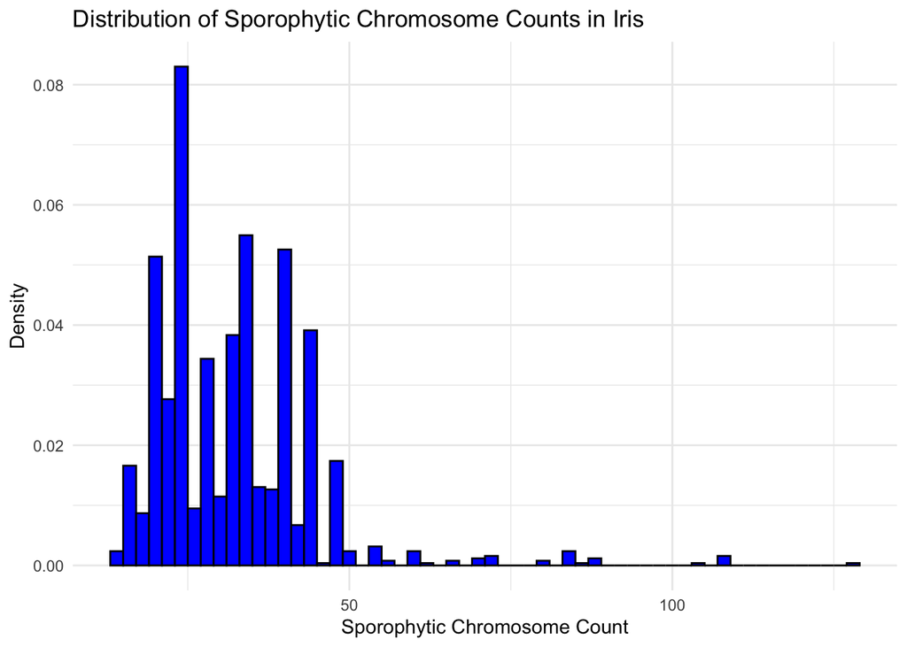

```r
ggplot(iris_chrom_clean, aes(x = sporophytic)) +
  geom_histogram(aes(y = after_stat(density)),
                 binwidth = 2,
                 fill = "blue",
                 color = "black") +
  labs(title = "Distribution of Sporophytic Chromosome Counts in Iris",
       x = "Sporophytic Chromosome Count",
       y = "Density") +
  theme_minimal()
```

## Question 3

The mode sporophytic chromosome number for Iris Setosa was 38, for Iris Virginica was 70, and for Iris Versicolor was 108. Since the chromosome numbers are all different to each other it is supports the argument that these represent three different species rather than different forms of one species.

# Part IV: Producing a scientific argument

## Question 1

The morphological data shows a separation between each of the species, especially with the petal length and petal width. Iris setosa was very separate from the other two species. Iris versicolor and Iris virginica showed some overlap but there was still a separation. The morphological data showed evidence that supported there being three separate species. The geographical data showed some overlap in the regions for all species and so did the temporal data showing some overlap during flowering times for all species. However, the overlap doesn’t mean they are the same species, specially since other data proved otherwise. The chromosomal data showed a different mode for each of the different species which means there’s genetic differences. This provides the strongest support that there is a separation between the species and they are all different types of species. I think the chromosomal data was the most compelling because the different genetic differences means that there would be less successful reproduction between the species which supports the idea of reproductive separation. I think that Anderson’s original designations of the species were correct. The geographical and temporal data retracted from his designation, but the chromosomal and morphological data helped add evidence to his initial hypothesis. The chromosomal data causes me to believe that these organisms represent three different separate species because of the genetic differences.